# Bayesian Stats, Meeting 2 Homework

Adam Clark

2025-10-27

Try analyzing the two datasets below as a practice problem for homework.

## Problem 1:

Look at the following example analysis. I’ve included all code that you need to make the dataset and to analyse it using the `lme` function.

What are the fixed and random effects for the model? What is the residual variance? What is the variance across the random effects (i.e. the standard deviation of the Gaussian prior)? What assumptions are we making about this regression?

No need to submit these answers, but see whether you can match the outputs from the regression to the values used to create the simulated data. We’ll go thorough the results in class next time we meet.

```r
require(nlme) # load package
```

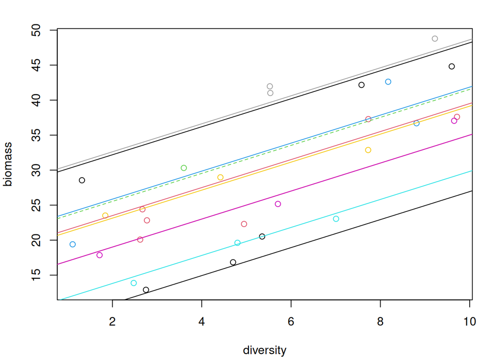

```r
# make data for example analysis 1
set.seed(231011)
n_blocks = 10

intercepts = rnorm(n_blocks, 20, 8)
slopes = 2
error = 2
bdat = data.frame(plot = 1:3,
                  block = rep(1:n_blocks, each = 3),
                  diversity = runif(n_blocks*3, 1, 10),
                  biomass = NA)
bdat$biomass=intercepts[bdat$block] + slopes*bdat$diversity + rnorm(nrow(bdat), 0, error)
bdat=bdat[bdat$block!=3 | bdat$plot==bdat$block,]

write.csv(bdat, "dataset_1.csv", row.names = FALSE)

# plot
par(mar=c(4,4,2,2))
plot(biomass~diversity, col = block, data = bdat)
for(i in 1:n_blocks) {
  if(i==3) {
    abline(intercepts[i], slopes, col = i, lty=2)
  } else {
    abline(intercepts[i], slopes, col = i)
  }
}
```

```r
# analyse
require(nlme)
mod = lme(biomass~diversity, random = ~1|block, data = bdat)
summary(mod)
```

```
## Linear mixed-effects model fit by REML
##   Data: bdat
##        AIC      BIC   logLik
##   158.6864 163.7188 -75.3432
##
## Random effects:
##  Formula: ~1 | block
##         (Intercept) Residual
## StdDev:    6.731147 2.074569
##
## Fixed effects:  biomass ~ diversity
##                 Value Std.Error DF   t-value p-value
## (Intercept) 16.927208 2.3065204 17  7.338851       0
## diversity    2.336225 0.1507222 17 15.500209       0
##  Correlation:
##           (Intr)
## diversity -0.341
##
## Standardized Within-Group Residuals:
##        Min         Q1        Med         Q3        Max
## -1.3099724 -0.6616612  0.1561555  0.4924559  2.2984436
##
## Number of Observations: 28
## Number of Groups: 10
```

```r
fixef(mod)
```

```
## (Intercept)   diversity
##   16.927208    2.336225
```

```r
ranef(mod)
```

```
##    (Intercept)
## 1    6.9651528
## 2   -3.6068915
## 3    4.5484033
## 4    1.8353849
## 5   -8.9212941
## 6   -3.4188947
## 7    0.6142543
## 8   10.8601769
## 9   -9.8324961
## 10   0.9562042
```

```r
VarCorr(mod)
```

```
## block = pdLogChol(1)
##             Variance  StdDev
## (Intercept) 45.308337 6.731147
## Residual     4.303835 2.074569
```

## Problem 2:

Now, try running an analysis yourself. Use the code below to load the simulated dataset (you may need to change your working directory first using the `setwd` command, or in the menu under “Session” -> “Set Working Directory”). For reference I’ve included the code for plotting the data:

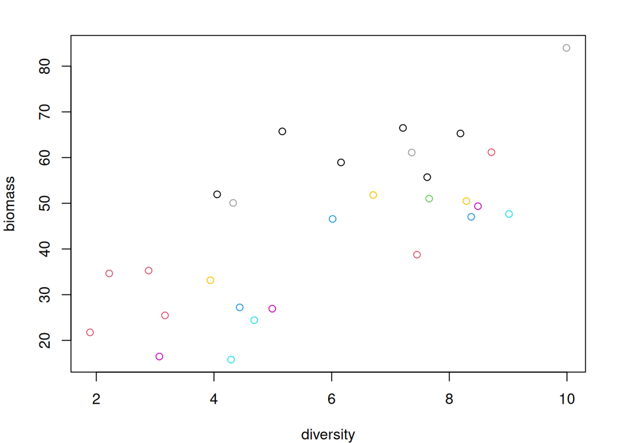

```r
bdat = read.csv("dataset_2.csv") # load data

# plot
par(mar=c(4,4,2,2))
plot(biomass~diversity, col = block, data = bdat)
```

Try answering the same questions as listed above, based on your fitted model. Again, no need to submit anything, but please to try to work through this yourself, as we will discuss the results in class when we next meet.

## Bonus question:

How could we calculate R-squared for this system (remember the formula we discussed briefly in class). Can we calculate separate estimates for the goodness of fit for the random effects estimates, vs. the fixed effects estimates?

We’ll discuss this in class the next time we meet.